# Growth Curve Report

Randy L Coryell

June 22, 2016

## Overview of Growth Study

### Strains:

> > > > ES114

> > > > ET401

> > > > EM17

> > *Note* All cultures were derived from a single colony, isolated on CAM plates (2.5ug/mL) and grown in liquid SWT (100mL) overnight. These overnight cultures were used to innoculate fresh SWT (100mL) media and grown at 225rpm and 28C for 1.5h. After taking a turbity measurement via spectrophotometry, each strain was diluted by placing a volume of this 1.5h culture into 100ml of fresh SWT. An initial OD was taken and the cultures were then placed into a shaking incubator @ 28C and 225RPM for the study.

> I want to walk down the street and have people say ‘There goes Roy Hobbs, the best to ever play the game’.

> > Robert Redford, The Natural

## Installation of R packages

Certain R packages, available on the CRAN repository, are required for this analysis.

```
install.packages(c('reshape2', 'dplyr', 'ggplot2'))
```

## Raw Data

In order to generate growth curves from the raw data, it first must be recorded as a CSV file in MSEXCEL and then loaded into memory in R.

```r
rawdata <- read.csv("/Users/randycoryell/Growth Curve/Growth Curve/06212016_CAM_VS_NOCAMcurve.csv")

print(rawdata)
```

```
##   Time Temp ES114CAM ES114NO ET401CAM ET401NO EM17CAM EM17NO
## 1    0   28    0.016   0.062    0.013   0.060   0.082  0.090
## 2   30   28    0.257   0.258    0.187   0.257   0.146  0.126
## 3   60   28    0.389   0.430    0.326   0.355   0.143  0.135
## 4   90   28    0.476   0.507    0.485   0.513   0.143  0.134
## 5  120   28    0.618   0.671    0.734   0.747   0.151  0.130
## 6  180   28    0.973   1.040    1.120   1.230   0.106  0.131
## 7  240   28    1.450   1.530    1.660   1.560   0.175  0.210
## 8  300   28    1.730   1.880    1.900   1.860   0.164  0.436
## 9  360   28    2.170   2.310    2.020   2.000   0.178  0.795
```

## Tidy the data

A reshaping of the data matrix is required in order to futher analyze the data set.

```r
library(reshape2)

reshaped <- melt(rawdata, id=c("Time", "Temp"), variable.name="Strain",
value.name="OD600")
```

Summary statistics can be called upon for the reshaped data

```r
summary(reshaped)
```

```
##       Time            Temp         Strain      OD600
##  Min.   :  0.0   Min.   :28   ES114CAM:9   Min.   :0.0130
##  1st Qu.: 60.0   1st Qu.:28   ES114NO :9   1st Qu.:0.1437
##  Median :120.0   Median :28   ET401CAM:9   Median :0.4095
##  Mean   :153.3   Mean   :28   ET401NO :9   Mean   :0.6902
##  3rd Qu.:240.0   3rd Qu.:28   EM17CAM :9   3rd Qu.:1.1000
##  Max.   :360.0   Max.   :28   EM17NO  :9   Max.   :2.3100
```

Now we need to take a quick look at the reshaped matrix to check for farmatting errors

```r
head(reshaped)
```

```
##   Time Temp   Strain OD600
## 1    0   28 ES114CAM 0.016
## 2   30   28 ES114CAM 0.257
## 3   60   28 ES114CAM 0.389
## 4   90   28 ES114CAM 0.476
## 5  120   28 ES114CAM 0.618
## 6  180   28 ES114CAM 0.973
```

When the data is replicated, there would need to be a nesting or grouping performed, this step would be useful for replicates in experimental evolution studies

```r
grouped <- group_by(reshaped, Strain)
```

Sice these are single reads from the spectrophotometer, no confidence interval can be established, however an approximate growth curve can be produced.

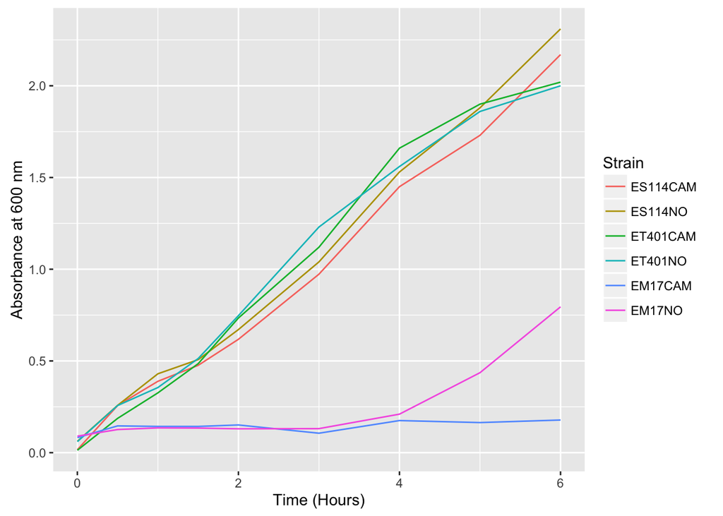

```r
library(ggplot2)
print(ggplot(data=reshaped, aes(x=Time/60, y=OD600, color=Strain)) + geom_line() + labs(x="Time (Hours)", y="Absorbance at 600 nm"))
```